## DATA 37711_Assignment 1

# Adrian Cao

## Question 1: Utility and Decision

# (a)

Let $U(y) = y$ be Victor's utility function, where $y$ is the amount of money he has. His expected utility is:

$$ \mathbb{E}[U(x)] = 0.85 \times (d + x) + 0.15 \times (d - x), $$ where $d$ is his initial wealth, and $x$ is the amount he bets on Biden winning.

To maximize the expected utility, we differentiate $\mathbb{E}[U(x)]$ with respect to $x$:

$$ \frac{d}{dx} \mathbb{E}[U(x)] = 0.85 - 0.15 = 0.7. $$

Since the derivative is positive, the expected utility increases as $x$ increases. Thus, to maximize his expected utility, Victor should bet his entire wealth, i.e., $x = d$.

**Conclusion**: If Victor’s utility function is linear in money, he will bet all his wealth $d$ on Biden winning. However, a linear utility function does not account for risk aversion and is not very realistic.

# (b)

Now, the utility function is $U(y) = \log(y)$, which represents risk aversion. Victor's expected utility becomes:

$$ \mathbb{E}[U(x)] = 0.85 \log(d + x) + 0.15 \log(d - x). $$

To find the optimal bet size $x$, we differentiate the expected utility with respect to $x$:

$$ \frac{d}{dx} \mathbb{E}[U(x)] = 0.85 \frac{1}{d + x} - 0.15 \frac{1}{d - x}. $$

Setting the derivative equal to zero to find the critical point:

$$ 0.85 \frac{1}{d + x} = 0.15 \frac{1}{d - x}. $$

Multiply both sides by $(d + x)(d - x)$:

$$ 0.85 (d - x) = 0.15 (d + x). $$

Simplifying:

$$ 0.85 d - 0.85 x = 0.15 d + 0.15 x, $$

$$ 0.7 d = x. $$

Thus, Victor should bet $70\%$ of his wealth, or $x = 0.7d$, on Biden winning.

# (c)

From part (b), Victor would bet $0.7d$. If your net worth is $500,000, this means you would bet:

$$ 0.7 \times 500,000 = 350,000. $$

Whether you would personally make this bet depends on your risk tolerance. While Victor’s utility function suggests betting 70% of his wealth based on the odds and his belief in Biden's victory, most individuals would consider this a risky decision. A more risk-averse individual might choose to bet a smaller portion of their wealth.

## Question 2: Cross Entropy as proper scoring rule

Let $Y$ be a binary random variable (i.e., $Y \in \{0, 1\}$), and let $X$ be the covariates. A loss function $L$ on categorical data is called a **proper scoring rule** if the predictive function $f^*$ that minimizes the implied risk is the conditional probability $P(Y | X = x)$.

The **Cross Entropy loss** for binary classification is given by: $$ L(Y, f(X)) = - Y \log(f(X)) - (1 - Y) \log(1 - f(X)), $$ where $f(X)$ represents the predicted probability that $Y = 1$ given $X$, i.e., $f(X) = P(Y = 1 | X)$.

The **expected risk** associated with the loss function $L(Y, f(X))$ is: $$ R(f) = \mathbb{E}_{X, Y} [L(Y, f(X))]. $$ We need to minimize this expected risk to find the optimal predictive function $f^*(X)$.

The expected risk can be written as: $$ R(f) = \mathbb{E}_{X,Y} \left[ - Y \log(f(X)) - (1 - Y) \log(1 - f(X)) \right]. $$ We can expand this using the law of total expectation: $$ R(f) = \mathbb{E}_X \left[ \mathbb{E}_Y \left[ - Y \log(f(X)) - (1 - Y) \log(1 - f(X)) \mid X \right] \right]. $$ Let $p(X) = P(Y = 1 \mid X)$ be the true conditional probability that $Y = 1$ given $X$. Then, we have: $$ R(f) = \mathbb{E}_X \left[ - p(X) \log(f(X)) - (1 - p(X)) \log(1 - f(X)) \right]. $$

To minimize the expected risk, we differentiate the risk $R(f)$ with respect to $f(X)$. The derivative is: $$ \frac{d}{df(X)} R(f) = - \frac{p(X)}{f(X)} + \frac{1 - p(X)}{1 - f(X)}. $$ Setting this derivative equal to zero to find the critical points: $$ - \frac{p(X)}{f(X)} + \frac{1 - p(X)}{1 - f(X)} = 0. $$ Multiplying both sides by $f(X)(1 - f(X))$, we get: $$ - p(X) (1 - f(X)) + (1 - p(X)) f(X) = 0. $$ Expanding and simplifying: $$ - p(X) + p(X) f(X) + f(X) - p(X) f(X) = 0, $$ $$ f(X) = p(X). $$

The function $f^*(X)$ that minimizes the expected risk is given by $f^*(X) = P(Y = 1 \mid X)$, which is the true conditional probability. Thus, we have shown that the Cross Entropy loss is a **proper scoring rule**.

## Question 3: Constent step size in finite sample

In practice, machine learning models are typically trained on **finite datasets**, and the objective is to achieve good generalization performance rather than to precisely minimize the objective function. While convergence theory requires the step size $\rho_t$ to decay (i.e., $\sum \rho_t^2 < \infty$) for stochastic gradient descent (SGD) to converge to the global minimum, this is primarily relevant for **infinite sample** settings. In the finite sample setting, it is often reasonable to use a constant step size because it allows for faster learning and avoids the vanishing updates that occur with decaying step sizes. Constant step sizes help the model explore the parameter space more thoroughly, allowing it to escape poor local minima or saddle points and find solutions that generalize well to unseen data, even if the exact convergence conditions are violated.

In conclusion, using a constant step size can be reasonable because:

- The number of iterations is finite, so exact convergence is not necessary.
- Constant step size helps balance bias and variance, which improves generalization.
- It allows for faster convergence to a near-optimal solution, which is often sufficient in practical machine learning.
- Early stopping can regularize the learning process, making decaying step sizes less important.

## Question 4: Testing Residuals for Normality

### Step 1: Load and Preprocess the Dataset

We load the ALE dataset and split it into predictors (the first four variables) and the target variable (ALE). We normalize the predictors if necessary and split the data into training and testing sets.

### Step 2: Fit Machine Learning Models

We fit several models from the `sklearn` package, such as:

- Linear regression
- Support Vector Machine (SVM) regression
- Decision Tree regression

The residuals are calculated as: [ \text{residuals} = Y_{\text{true}} - Y_{\text{pred}} ] where ( Y_{\text{true}} ) are the actual ALE values, and ( Y_{\text{pred}} ) are the predicted values from the models.

### Step 3: Normality Testing

To check if the residuals are approximately normally distributed, we perform the following tests:

- **QQ Plot**: A QQ plot compares the distribution of the residuals to a normal distribution. If the residuals follow a straight line, they are approximately normal.
- **Normality Test**: We apply `scipy.stats.normaltest`, which returns a p-value. If the p-value is small (e.g., less than 0.05), we reject the null hypothesis that the residuals are normally distributed.

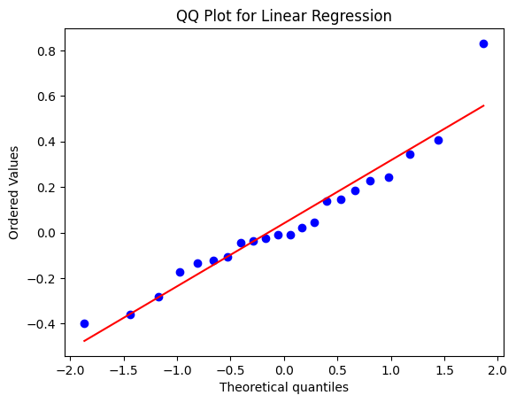

```
Linear Regression: Normaltest p-value = 0.0260
```

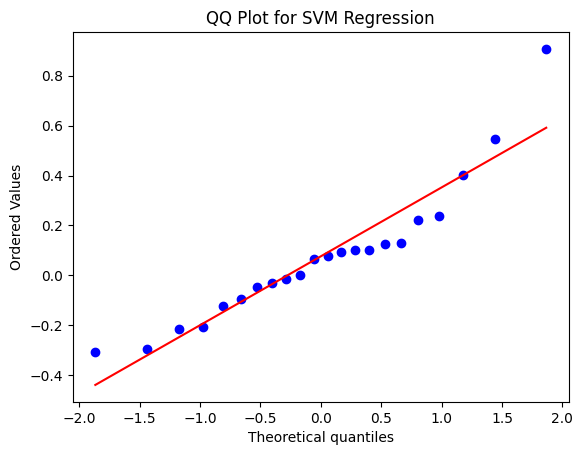

```
SVM Regression: Normaltest p-value = 0.0043
```

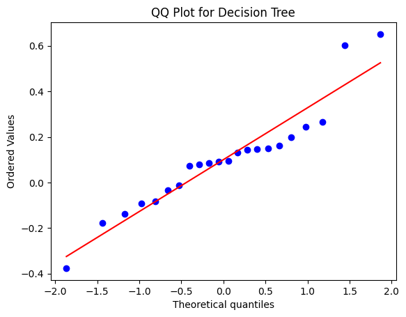

```
Decision Tree: Normaltest p-value = 0.1140
```

```python
import pandas as pd
import numpy as np
from sklearn.model_selection import train_test_split
from sklearn.linear_model import LinearRegression
from sklearn.svm import SVR
from sklearn.tree import DecisionTreeRegressor
from sklearn.metrics import mean_squared_error
import matplotlib.pyplot as plt
import scipy.stats as stats
import seaborn as sns

# Load the ALE dataset
data = pd.read_csv('mcs_ds_edited_iter_shuffled.csv')

# Extract features and target
X = data.iloc[:, :4]  # First four variables as predictors
y = data['ale']  # ALE target

# Split into training and testing sets
X_train, X_test, y_train, y_test = train_test_split(X, y, test_size=0.2, random_state=42)

# Initialize models
models = {
    'Linear Regression': LinearRegression(),
    'SVM Regression': SVR(),
    'Decision Tree': DecisionTreeRegressor()
}

# Fit models and compute residuals
residuals = {}

for name, model in models.items():
    model.fit(X_train, y_train)
    y_pred = model.predict(X_test)
    residuals[name] = y_test - y_pred

    # Plot QQ plot
    plt.figure()
    stats.probplot(residuals[name], dist="norm", plot=plt)
    plt.title(f'QQ Plot for {name}')
    plt.show()

    # Perform normality test
    stat, p_value = stats.normaltest(residuals[name])
    print(f'{name}: Normaltest p-value = {p_value:.4f}')
```

## Question 5

# Classification

```python
import numpy as np
import torch
from sklearn.datasets import load_breast_cancer
from sklearn.model_selection import train_test_split
from sklearn.linear_model import LogisticRegression
from sklearn.metrics import accuracy_score

# Load dataset
data = load_breast_cancer()
X = data['data']
y = data['target']

# Split dataset (80/20 split)
X_train, X_test, y_train, y_test = train_test_split(X, y, test_size=0.2, random_state=42)

# Baseline using sklearn's logistic regression
baseline_model = LogisticRegression(max_iter=1000)
baseline_model.fit(X_train, y_train)
y_pred_baseline = baseline_model.predict(X_test)

# Calculate accuracy
baseline_accuracy = accuracy_score(y_test, y_pred_baseline)
print(f"Baseline Logistic Regression Accuracy: {baseline_accuracy:.4f}")
```

```
Baseline Logistic Regression Accuracy: 0.9561
```

```python
# (a)

import torch
import torch.nn as nn
import torch.optim as optim
import torch.nn.functional as F

# Convert data to PyTorch tensors
X_train_torch = torch.tensor(X_train, dtype=torch.float32)
X_test_torch = torch.tensor(X_test, dtype=torch.float32)
y_train_torch = torch.tensor(y_train, dtype=torch.float32).unsqueeze(1)  # reshape to column vector
y_test_torch = torch.tensor(y_test, dtype=torch.float32).unsqueeze(1)

# Logistic regression model
class LogisticRegressionModel(nn.Module):
    def __init__(self, input_dim):
        super(LogisticRegressionModel, self).__init__()
        self.linear = nn.Linear(input_dim, 1)  # Linear layer: w^T x + b

    def forward(self, x):
        return torch.sigmoid(self.linear(x))  # Sigmoid activation function

# Initialize model, loss function, and optimizer
input_dim = X_train.shape[1]
model = LogisticRegressionModel(input_dim)
criterion = nn.BCELoss()  # Binary Cross Entropy Loss
optimizer = optim.SGD(model.parameters(), lr=0.01)

# Train the model
num_epochs = 1000
for epoch in range(num_epochs):
    # Forward pass: Compute predictions and loss
    outputs = model(X_train_torch)
    loss = criterion(outputs, y_train_torch)

    # Backward pass and optimization
    optimizer.zero_grad()
    loss.backward()
    optimizer.step()

    # Print loss every 100 epochs
    if (epoch+1) % 100 == 0:
        print(f'Epoch [{epoch+1}/{num_epochs}], Loss: {loss.item():.4f}')

# Evaluate the model on test data
with torch.no_grad():
    y_pred_torch = model(X_test_torch)
    y_pred_torch = (y_pred_torch > 0.5).float()  # Threshold at 0.5

# Calculate accuracy
accuracy_torch = accuracy_score(y_test_torch, y_pred_torch)
print(f"PyTorch Logistic Regression Accuracy: {accuracy_torch:.4f}")
```

```
Epoch [100/1000], Loss: 37.1429
Epoch [200/1000], Loss: 37.1429
Epoch [300/1000], Loss: 37.1429
Epoch [400/1000], Loss: 37.1429
Epoch [500/1000], Loss: 37.1429
Epoch [600/1000], Loss: 37.1429
Epoch [700/1000], Loss: 37.1429
Epoch [800/1000], Loss: 37.1429
Epoch [900/1000], Loss: 37.1429
Epoch [1000/1000], Loss: 37.1429
PyTorch Logistic Regression Accuracy: 0.6228
```

The PyTorch implementation of logistic regression has significantly lower accuracy compared to the baseline model from sklearn.

```python
# (b)
from torch.distributions import Normal

# Probit regression model
class ProbitRegressionModel(nn.Module):
    def __init__(self, input_dim):
        super(ProbitRegressionModel, self).__init__()
        self.linear = nn.Linear(input_dim, 1)  # Linear layer: w^T x + b

    def forward(self, x):
        z = self.linear(x)
        return Normal(0, 1).cdf(z)  # CDF of standard normal distribution

# Initialize probit model, loss function, and optimizer
model_probit = ProbitRegressionModel(input_dim)
criterion = nn.BCELoss()  # Binary Cross Entropy Loss (same as before)
optimizer = optim.SGD(model_probit.parameters(), lr=0.01)

# Train the probit model
for epoch in range(num_epochs):
    # Forward pass: Compute predictions and loss
    outputs = model_probit(X_train_torch)
    loss = criterion(outputs, y_train_torch)

    # Backward pass and optimization
    optimizer.zero_grad()
    loss.backward()
    optimizer.step()

    # Print loss every 100 epochs
    if (epoch+1) % 100 == 0:
        print(f'Epoch [{epoch+1}/{num_epochs}], Probit Loss: {loss.item():.4f}')

# Evaluate the probit model on test data
with torch.no_grad():
    y_pred_probit = model_probit(X_test_torch)
    y_pred_probit = (y_pred_probit > 0.5).float()  # Threshold at 0.5

# Calculate accuracy
accuracy_probit = accuracy_score(y_test_torch, y_pred_probit)
print(f"PyTorch Probit Regression Accuracy: {accuracy_probit:.4f}")
```

```
Epoch [100/1000], Probit Loss: 37.1429
Epoch [200/1000], Probit Loss: 37.1429
Epoch [300/1000], Probit Loss: 37.1429
Epoch [400/1000], Probit Loss: 37.1429
Epoch [500/1000], Probit Loss: 37.1429
Epoch [600/1000], Probit Loss: 37.1429
Epoch [700/1000], Probit Loss: 37.1429
Epoch [800/1000], Probit Loss: 37.1429
Epoch [900/1000], Probit Loss: 37.1429
Epoch [1000/1000], Probit Loss: 37.1429
PyTorch Probit Regression Accuracy: 0.6228
```

With the change of the Probit model, it does not help with the better predicting. They still have significantly worse performance compared to the baseline model.

# Regression

```python
from sklearn.model_selection import train_test_split
from sklearn.linear_model import LinearRegression
from sklearn.metrics import mean_absolute_error

# Load the ALE dataset
data = pd.read_csv('mcs_ds_edited_iter_shuffled.csv')

# Assuming ALE dataset is loaded into a DataFrame 'df'
X = data.drop('ale', axis=1).values  # Features
y = data['ale'].values  # Target variable (ALE)

# Split into training and testing sets (80/20)
X_train, X_test, y_train, y_test = train_test_split(X, y, test_size=0.2, random_state=42)

# Baseline model using sklearn's linear regression
baseline_model = LinearRegression()
baseline_model.fit(X_train, y_train)
y_pred_baseline = baseline_model.predict(X_test)

# Evaluate baseline performance using Mean Absolute Error (MAE)
baseline_mae = mean_absolute_error(y_test, y_pred_baseline)
print(f"Baseline Linear Regression MAE: {baseline_mae:.4f}")
```

```
Baseline Linear Regression MAE: 0.1861
```

```python
import torch
import torch.nn as nn
import torch.optim as optim
from sklearn.preprocessing import StandardScaler
from sklearn.metrics import mean_absolute_error

# Standardize the data
scaler = StandardScaler()
X_train_scaled = scaler.fit_transform(X_train)
X_test_scaled = scaler.transform(X_test)

# Convert scaled data to tensors
X_train_torch = torch.tensor(X_train_scaled, dtype=torch.float32)
X_test_torch = torch.tensor(X_test_scaled, dtype=torch.float32)
y_train_torch = torch.tensor(y_train, dtype=torch.float32).unsqueeze(1)  # Reshape to column vector
y_test_torch = torch.tensor(y_test, dtype=torch.float32).unsqueeze(1)

# Define the linear regression model
class LinearRegressionModel(nn.Module):
    def __init__(self, input_dim):
        super(LinearRegressionModel, self).__init__()
        self.linear = nn.Linear(input_dim, 1)  # Linear model: w^T x + b

    def forward(self, x):
        return self.linear(x)  # f(x) = w^T x + b

# Initialize model, loss function, and optimizer
input_dim = X_train.shape[1]
model = LinearRegressionModel(input_dim)
criterion = nn.MSELoss()  # Mean squared error loss
optimizer = optim.SGD(model.parameters(), lr=0.001)  # Lower learning rate

# Initialize weights properly
def initialize_weights(m):
    if isinstance(m, nn.Linear):
        nn.init.kaiming_uniform_(m.weight)
        nn.init.zeros_(m.bias)

model.apply(initialize_weights)

# Train the model with gradient clipping
num_epochs = 1000
for epoch in range(num_epochs):
    # Forward pass: compute predictions and loss
    outputs = model(X_train_torch)
    loss = criterion(outputs, y_train_torch)

    # Backward pass and optimization
    optimizer.zero_grad()
    loss.backward()

    # Gradient clipping to prevent exploding gradients
    torch.nn.utils.clip_grad_norm_(model.parameters(), max_norm=1.0)

    optimizer.step()

    # Print loss every 100 epochs
    if (epoch + 1) % 100 == 0:
        print(f'Epoch [{epoch+1}/{num_epochs}], Loss: {loss.item():.4f}')

# Evaluate on the test set
with torch.no_grad():
    y_pred_torch = model(X_test_torch)

    # Check for NaN or infinite values
    if torch.isnan(y_pred_torch).any() or torch.isinf(y_pred_torch).any():
        print("NaN or infinity detected in predictions!")

    mae_torch = mean_absolute_error(y_test_torch, y_pred_torch)
    print(f"PyTorch Linear Regression MAE: {mae_torch:.4f}")
```

```
Epoch [100/1000], Loss: 5.0111
Epoch [200/1000], Loss: 4.5211
Epoch [300/1000], Loss: 4.0575
Epoch [400/1000], Loss: 3.6204
Epoch [500/1000], Loss: 3.2094
Epoch [600/1000], Loss: 2.8245
Epoch [700/1000], Loss: 2.4655
Epoch [800/1000], Loss: 2.1322
Epoch [900/1000], Loss: 1.8244
Epoch [1000/1000], Loss: 1.5421
PyTorch Linear Regression MAE: 0.9404
```

The PyTorch model using the normal distribution loss is currently underperforming compared to the baseline model.

```python
import torch
import torch.nn as nn
import torch.optim as optim
from sklearn.preprocessing import StandardScaler
from sklearn.metrics import mean_absolute_error
from torch.distributions import StudentT

# Standardize the data
scaler = StandardScaler()
X_train_scaled = scaler.fit_transform(X_train)
X_test_scaled = scaler.transform(X_test)

# Convert scaled data to tensors
X_train_torch = torch.tensor(X_train_scaled, dtype=torch.float32)
X_test_torch = torch.tensor(X_test_scaled, dtype=torch.float32)
y_train_torch = torch.tensor(y_train, dtype=torch.float32).unsqueeze(1)  # Reshape to column vector
y_test_torch = torch.tensor(y_test, dtype=torch.float32).unsqueeze(1)

# Define the linear regression model
class LinearRegressionModel(nn.Module):
    def __init__(self, input_dim):
        super(LinearRegressionModel, self).__init__()
        self.linear = nn.Linear(input_dim, 1)  # Linear model: w^T x + b

    def forward(self, x):
        return self.linear(x)  # f(x) = w^T x + b

# Initialize model, optimizer, and t-distribution parameters
input_dim = X_train.shape[1]
model = LinearRegressionModel(input_dim)
optimizer = optim.SGD(model.parameters(), lr=0.001)  # Lower learning rate
nu = 5  # Degrees of freedom for the t-distribution

# Initialize weights properly
def initialize_weights(m):
    if isinstance(m, nn.Linear):
        nn.init.kaiming_uniform_(m.weight)
        nn.init.zeros_(m.bias)

model.apply(initialize_weights)

# Define a custom t-distribution loss function using negative log-likelihood
def t_distribution_loss(y_true, y_pred, nu=5):
    t_dist = StudentT(nu)  # Create the StudentT distribution with nu degrees of freedom
    residuals = y_true - y_pred  # Calculate residuals
    log_likelihood = t_dist.log_prob(residuals)  # Calculate log probability of residuals
    return -log_likelihood.mean()  # Return the negative log-likelihood

# Train the model using SGD
num_epochs = 1000
for epoch in range(num_epochs):
    # Forward pass: compute predictions and loss
    outputs = model(X_train_torch)
    loss = t_distribution_loss(y_train_torch, outputs, nu=5)

    # Backward pass and optimization
    optimizer.zero_grad()
    loss.backward()

    # Gradient clipping to prevent exploding gradients
    torch.nn.utils.clip_grad_norm_(model.parameters(), max_norm=1.0)

    optimizer.step()

    # Print loss every 100 epochs
    if (epoch + 1) % 100 == 0:
        print(f'Epoch [{epoch+1}/{num_epochs}], T-Loss: {loss.item():.4f}')

# Evaluate on the test set
with torch.no_grad():
    y_pred_t = model(X_test_torch)

    # Check for NaN or infinite values
    if torch.isnan(y_pred_t).any() or torch.isinf(y_pred_t).any():
        print("NaN or infinity detected in predictions!")

    mae_t_dist = mean_absolute_error(y_test_torch, y_pred_t)
    print(f"PyTorch Linear Regression (t-Distribution) MAE: {mae_t_dist:.4f}")
```

```
Epoch [100/1000], T-Loss: 1.7327
Epoch [200/1000], T-Loss: 1.6475
Epoch [300/1000], T-Loss: 1.5681
Epoch [400/1000], T-Loss: 1.4949
Epoch [500/1000], T-Loss: 1.4283
Epoch [600/1000], T-Loss: 1.3685
Epoch [700/1000], T-Loss: 1.3155
Epoch [800/1000], T-Loss: 1.2691
Epoch [900/1000], T-Loss: 1.2289
Epoch [1000/1000], T-Loss: 1.1944
PyTorch Linear Regression (t-Distribution) MAE: 0.4205
```